# Analiza in predikcija neplačnikov kreditov in posojil

Author

Sara Smajič

Published

October 14, 2024

## Naloga

Podanih imamo 12 različnih spremenljivk. Naša naloga je poiskati korelacijo med spremenljivko “DlqIn2Years”, kar pomeni, da je stranka zamujala ali pa sploh ni plačala kredita/posojila. Tako s številkami kot tudi z logičnimi povezavami poskušamo ugotoviti katere spremenljivke vplivajo na našo ciljno - odvisno spremenljivko.

## Reševanje naloge

Nalogo sem rešila s tremi priljubljenimi modeli, ki se pogosto uporabljajo pri analizi podatkov. Izrisala sem korelacijsko matriko in naučila oz. prilagodila linearni model ter natrenirala nevronsko mrežo. Te pa so bolj podrobno opisane v nadaljevanju.

## Korelacijska tabela

Kot že prej omenjeno, izračunala sem korelacijsko tabelo katera vrne korelacijske koeficiente, ki so kazalniki povezav med dvema spremenljivkama, njegov interval pa je med -1 in 1.

-1 je popolna negativna korelacija (ko se ena spremenljivka povečuje, se druga zmanjšuje), 0 pomeni, da korelacije ni in 1, da je popolna pozitivna korelacija(ko se ena spremenljivka povečuje, se tudi druga).

Izris ne pokaže samo številčno, ampak tudi vizualno - tam kjer je temnejše polje, večji je koeficient in tam kjer je svetlejše, manjši je. Temnejše obarvani oz. pozitivni so: “NoOfTime35-65DaysPastDueNotWorse”, “NoOfTimes90DaysLate”, “NoOfTime60-89DaysPastDueNotWorse”.

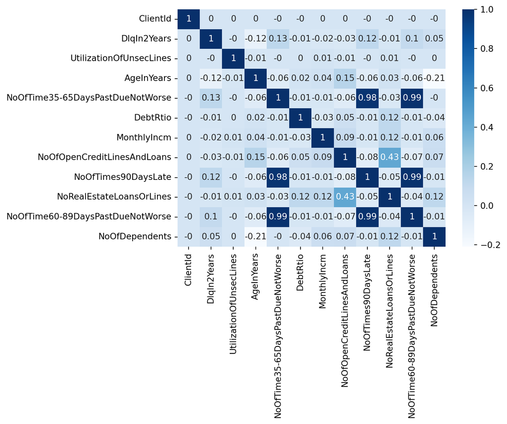

Figure 1: Korelacijska matrika

```python
import pandas as pd
import matplotlib.pyplot as plt
import seaborn as sns
import numpy as np
from sklearn import linear_model
from sklearn.metrics import mean_squared_error, r2_score
from sklearn.model_selection import train_test_split
from sklearn.neural_network import MLPClassifier
from sklearn.neural_network import MLPRegressor
from sklearn.metrics import classification_report, confusion_matrix
from sklearn.preprocessing import StandardScaler


df = pd.read_csv("cs-data.csv")

corr_mat = round(df.corr(), 2)

positive_corr = corr_mat
sns.heatmap(positive_corr, annot =True, cmap='Blues', mask = positive_corr.isnull())
plt.show() #vizualizacija matrike
```

## Linearni model

Največji rezulati so 3, 7 in 9 podatek, torej “NoOfTime35-65DaysPastDueNotWorse”, “NoOfTimes90DaysLate”, “NoOfTime60-89DaysPastDueNotWorse”.

```python
df = df.dropna(axis=0, how='any')
x = df.iloc[:,2:].values
y = df.iloc[:, 1].values

print(x.shape)

x_train, x_test, y_train, y_test = train_test_split(x, y, test_size = 0.2, random_state = 0)
scaler = StandardScaler()
x_train = scaler.fit_transform(x_train)
x_test = scaler.transform(x_test)

lin_reg = linear_model.LinearRegression()
lin_reg.fit(x_train, y_train)

lin_reg_pred = lin_reg.predict(x_test)
print("Coefficients:\n", lin_reg.coef_)
print("Intercept:\n", lin_reg.intercept_)

print("Mean squared error: %.2f" % mean_squared_error(y_test, lin_reg_pred))
#print(corr_mat) matrika
```

```
(120269, 10)
Coefficients:
 [-0.0006376  -0.02169043  0.17161968 -0.00091445 -0.00389411 -0.00332202
  0.16262872  0.00188415 -0.30619223  0.00487459]
Intercept:
 0.0691680091461826
Mean squared error: 0.06
```

## Nevronske mreže

V knjižnici sklearn sem poskusila natrenirati nevronsko mrežo, ki bi napovedala naš y. Mreža ni najbolj zanesljiva, saj so njene napake prevelike, je pa tudi eden izmed načinov, s katerim se da problem rešiti.

```python
mlp = MLPClassifier(hidden_layer_sizes=(8,8), activation="relu", solver="adam")
mlp.fit(x_train, y_train)

predict_train = mlp.predict(x_train)
predict_test = mlp.predict(x_test)

print(confusion_matrix(y_train, predict_train))
print(classification_report(y_train, predict_train))
```

```
[[88979   581]
 [ 5766   889]]
              precision    recall  f1-score   support

           0       0.94      0.99      0.97     89560
           1       0.60      0.13      0.22      6655

    accuracy                           0.93     96215
   macro avg       0.77      0.56      0.59     96215
weighted avg       0.92      0.93      0.91     96215
```